# How To Make Your Marketing Campaign Viral

Upload the dataset obtained from this [site](https://snap.stanford.edu/data/feather-deezer-social.html).

```r
library(igraph)
library(ggplot2)
library(knitr)
library(Matrix)

data <- read.csv("deezer_europe/deezer_europe_edges.csv", sep = ',', header = TRUE)

data <- as.matrix(data)+1

G = graph_from_edgelist(data, directed = FALSE)
A = as_adjacency_matrix(G)
n = vcount(G)
m = ecount(G)
```

## Checking Small world property

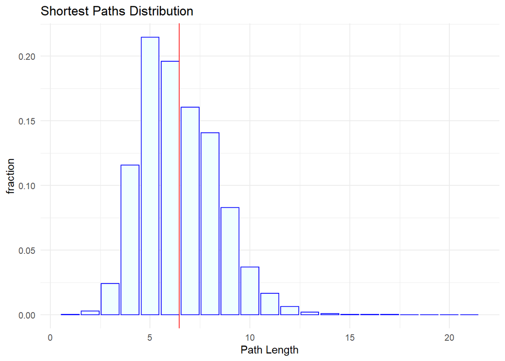

```r
global_trans <- transitivity(graph = G, type = "global")
local_trans <- transitivity(graph = G, type = "local")

rho = m/(n*(n-1)/2)

distribution_geodetics <- distance_table(G)$res #2 minutes
distribution_geodetics <- distribution_geodetics/sum(distribution_geodetics)

avg_path_lenght <- sum(
  distribution_geodetics*
    1:length(distribution_geodetics))

ggplot(data =
         data.frame(y = distribution_geodetics,       x=1:length(distribution_geodetics)),
       aes(x=x, y=y)
       ) +
  geom_col( color = 'blue', fill='azure')+
  geom_vline(aes(xintercept =  avg_path_lenght), color = 'red')+
  theme_minimal()+
  labs(title ='Shortest Paths Distribution', x = 'Path Length', y='fraction')
```

```r
#log(n)/log(2*m/n)

kable(data.frame('Global CC' = round(global_trans,4), 'Density' = round(rho,4),
                 'avg path lenght' = round(avg_path_lenght,2),
                 'log(n)/log(2m/n)' = round(log(n)/log(2*m/n),2) ) )
```

| Global.CC | Density | avg.path.lenght | log.n..log.2m.n. |
| --- | --- | --- | --- |
| 0.0959 | 2e-04 | 6.45 | 5.45 |

## Visualize the degree Distribution

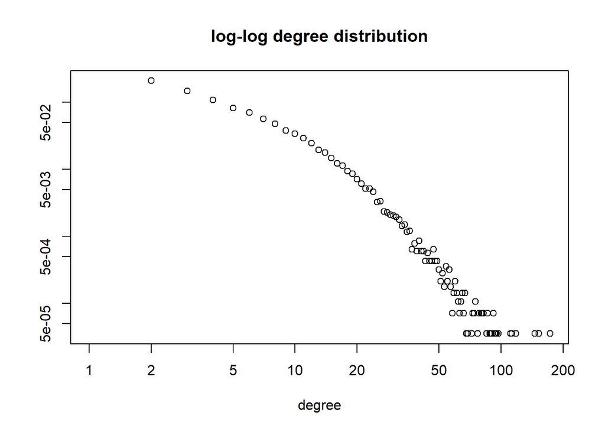

```r
degr_distr <- degree_distribution(graph = G)

plot(degr_distr, log = "xy", main = "log-log degree distribution", xlab = "degree", ylab = "", )
```

```r
lin_reg <- lm(log(degr_distr)~log(1:length(degr_distr)), subset = degr_distr>0)
summary(lin_reg)
```

```
##
## Call:
## lm(formula = log(degr_distr) ~ log(1:length(degr_distr)), subset = degr_distr >
##     0)
##
## Residuals:
##      Min       1Q   Median       3Q      Max
## -2.17274 -0.37209  0.04012  0.47816  1.19001
##
## Coefficients:
##                           Estimate Std. Error t value Pr(>|t|)
## (Intercept)                 2.4733     0.2621   9.439 3.81e-15 ***
## log(1:length(degr_distr))  -2.6999     0.0697 -38.737  < 2e-16 ***
## ---
## Signif. codes:  0 '***' 0.001 '**' 0.01 '*' 0.05 '.' 0.1 ' ' 1
##
## Residual standard error: 0.598 on 91 degrees of freedom
## Multiple R-squared:  0.9428, Adjusted R-squared:  0.9422
## F-statistic:  1501 on 1 and 91 DF,  p-value: < 2.2e-16
```

```r
C = exp(lin_reg$coefficients[1])
b = lin_reg$coefficients[2]
```

It follows a power law distribution $f_x(x) = 11.9x^{-2.7}$

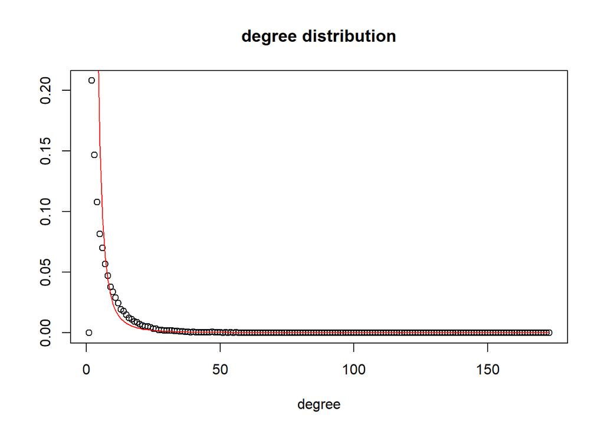

```r
axe = 1:length(degr_distr)

plot(degr_distr, main="degree distribution", ylab="",xlab="degree")
axe = 1:length(degr_distr)
lines(axe, C*(axe)^b, col='red')
```

## Degree correlation

```r
degree_correlation_func <- knn(G)$knnk

maxdegree <- length(degr_distr)
k_square <- sum(degr_distr * (1:maxdegree)^2)
k_mean <- sum(degr_distr * 1:maxdegree)
k_neutral <- k_square/k_mean

v <- 1:length(degree_correlation_func)

degr_cor_fit <- lm(degree_correlation_func ~ v,
                   subset = is.nan(degree_correlation_func) == FALSE)

summary(degr_cor_fit)
```

[output not shown]

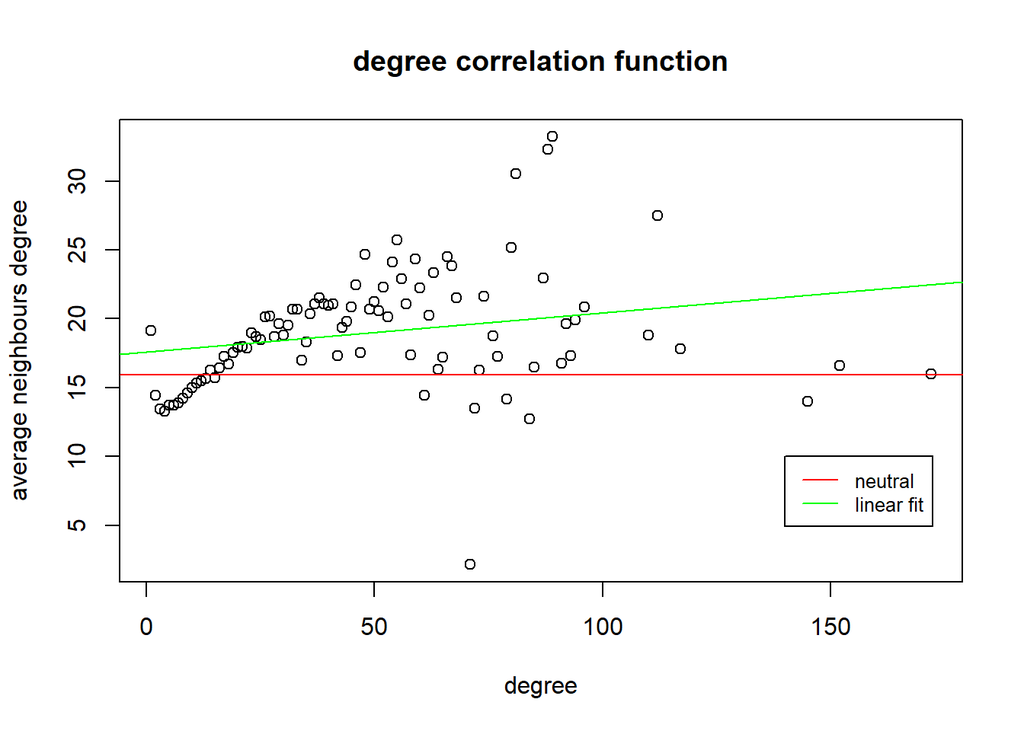

```r
plot(degree_correlation_func, main = "degree correlation function",
     xlab="degree", ylab="average neighbours degree")
abline(h = k_neutral, col = "red")
abline(a = degr_cor_fit$coefficients[1], b=degr_cor_fit$coefficients[2],
       col ="green")
legend(140, 10, legend=c("neutral", "linear fit"),
       col=c("red", "green"), lty=c(1,1), cex=0.8)
```

```r
assortativity_degree(G)
```

```
## [1] 0.104127
```

## Rich club Effect

we need to find the density of the subgraph induced by the fraction r of the most popular vertices

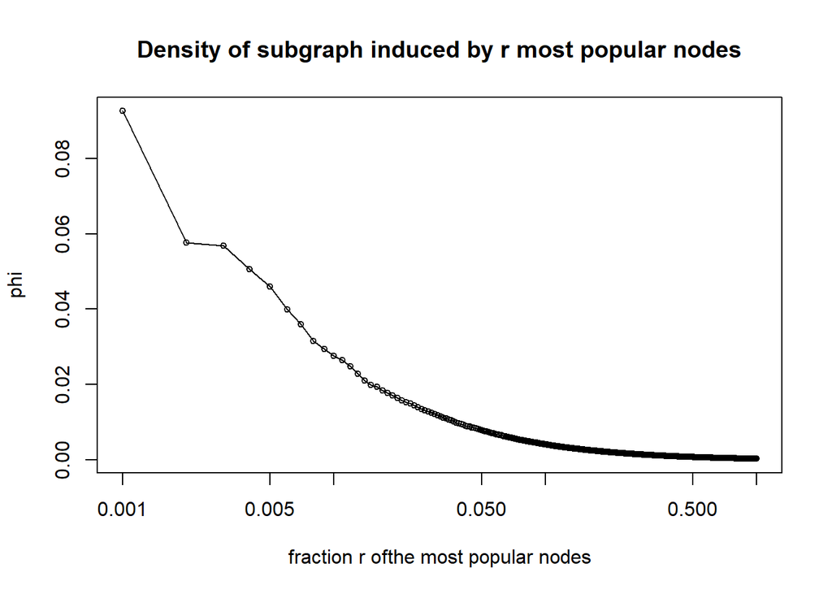

```r
degrees <- Matrix::colSums(A)
#this vector contains the id nodes in decreasing order w.r.t. degree
decreas_nodes_degree<-order(degrees, decreasing = TRUE)

density_induced<- function(nodes_id){
  #computes the density of the subgraph induced by nodes_id
  n_d <- length(nodes_id)
  return(sum(A[nodes_id,nodes_id])/(n_d*(n_d-1)))
}

r <- seq(from=0, to=1, by=0.001)
phi <- sapply(r,function(x){
  nodes_id <- decreas_nodes_degree[1:round(n*x,0)]
  return(density_induced(nodes_id))
})

plot(r, phi, log = "x", main="Density of subgraph induced by r most popular nodes", xlab="fraction r ofthe most popular nodes", type = 'o', cex=0.7)
```

## Homphily

Each vertex is labeled with 0, male, or 1, female. Are the links between the two groups significantly less than expected?

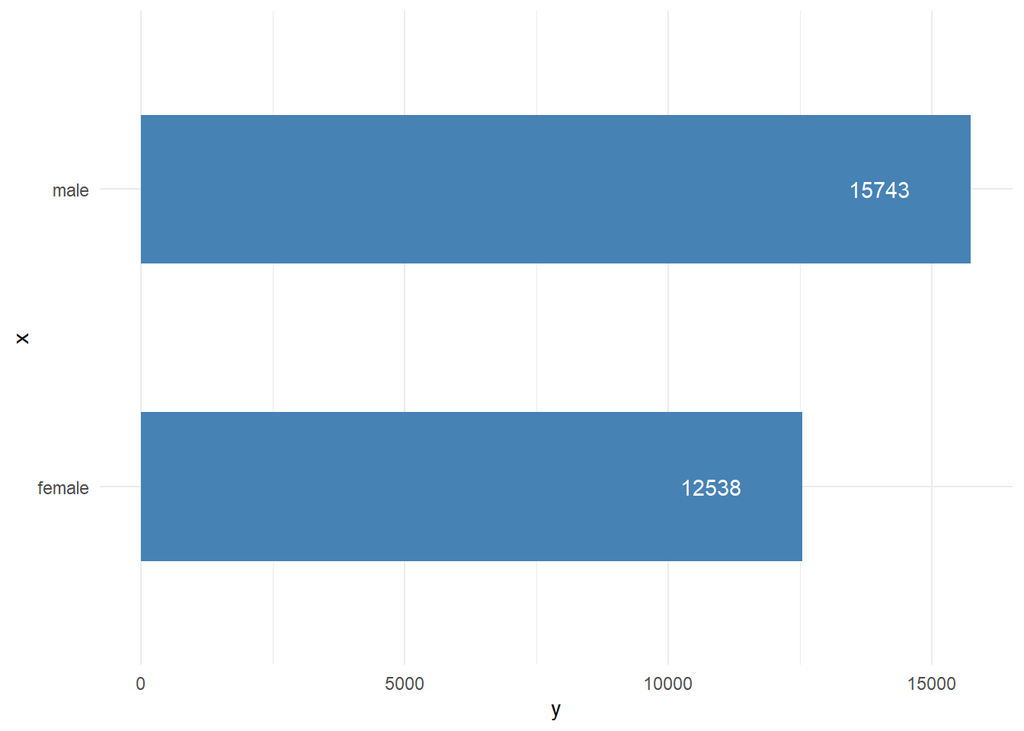

```r
sex <- read.csv("deezer_europe/sex.csv")
sex <- sex[,2]


ggplot(
  data = data.frame(x = c("female","male"),
                             y = c(sum(sex==1),sum(sex==0))
                             ),aes(x = x, y = y )
           )+
  geom_bar(stat = "identity", width = 0.5, fill="steelblue")+
  geom_text(aes(label = y), hjust = 2, color="white")+
  coord_flip()+ theme_minimal()
```

The expected number of edges between the two group under no homphily is $u_0 = 2p(1-p)$, where $p$ is the fraction of males.

```r
p <- sum(sex == 0)/n
groups <- sex
vertices = 1:n

u0 = 2*p*(1-p)

#actual fraction of nodes
u=sum(A[vertices[groups==0],vertices[groups == 1]])/m
u<u0
```

```
## [1] TRUE
```

It is smaller enough? We need to test! Let $X_{ij}$ a r.v. equal to 1 if (i,j) is a between-group edge and 0 otherwise. $H_0 : EX_{ij} = u_0$ versus $H_1: EX_{ij} < u_0$

```r
y = sqrt(m)*(u - u0)
#by CLT y is approx gaussian with mean 0 and variance u0(1-u0)
alpha = 0.05
theta = qnorm(alpha, mean = 0, sd = sqrt(u0*(1-u0)))
theta0 = theta/sqrt(m) + u0
u<theta0
```

```
## [1] TRUE
```

## Simulation of the diffusion of innovation

The function that perform the simulation has two parameters: * x, it can be a number or a vector of nodes id. If it is a number the starting nodes will be x random nodes. * the threshold q. The function returns a vector which for each timestamp gives the number of convinced nodes.

```r
degrees_inv <- 1/Matrix::colSums(A)

D_inv <- Diagonal(x = degrees_inv)
# it must be a sparse matrix

simulation <- function(x, q){
  status <- rep(FALSE, n) # a vector that link nodes to conviced (0 or 1)
  if( length(x) == 1){
    S = sample(x = 1:n, size = x, replace = FALSE)
  }else{
    S = x
  }
  n_v<-length(S)
  status[S] <- rep(TRUE,n_v)
  n_convinced <- c(0,n_v)
  stp <- 2

  while (n_convinced[stp]-n_convinced[stp-1] > 0){
    #a node can be convinced if the fraction of neighbours convinced p is
    # p*a>(1-p)*b => p > b/(a+b)=rho.
    # status*A*D_inv gives for each node the value p
    #print(paste("step ",stp," convinti ",sum(status)))

    status <- matrix(ifelse(status%*%A%*%D_inv > q, TRUE, FALSE), nrow = 1) | status
    n_convinced <- c(n_convinced, sum(status))
    stp <- stp+1
  }

  return(n_convinced)
}
```

Fixing $q=\frac{1}{3}$, we compare the case in which we choose the k-most popular nodes, the k-most close nodes and k random nodes.

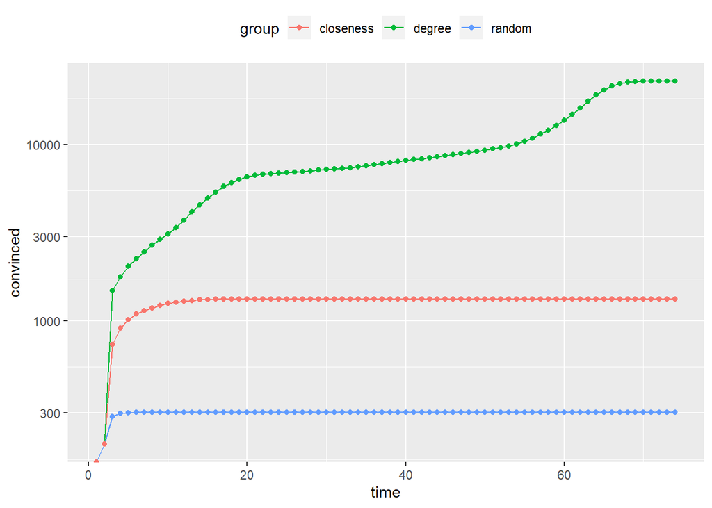

```r
q=1/3
k = 200

random_sim <- simulation(k,q)
n_r <- length(random_sim)

degree_sim <- simulation(decreas_nodes_degree[1:k],q)
n_d <- length(degree_sim)

close <- closeness(G)
decreas_nodes_close <- order(close, decreasing = TRUE)

closeness_sim <- simulation(decreas_nodes_close[1:k],q)
n_c <- length(closeness_sim)


n_max<-max(n_r,n_d,n_c)
time <- 1:n_max
df <- data.frame(time = time,
                 convinced = c(c(random_sim,rep(random_sim[n_r],n_max-n_r)),
                               c(degree_sim, rep(degree_sim[n_d],n_max-n_d)),
                           c(closeness_sim,rep(closeness_sim[n_c],n_max-n_c))),
                group = rep(c("random","degree","closeness"), each=n_max)
                )

ggplot(data = df, aes(x = time, y=convinced, group = group))+
  geom_line(aes(color = group))+geom_point(aes(color = group))+
  scale_y_log10()+theme(legend.position = "top")
```

### K-shell decomposition

The simulation is repeated using as starting nodes the ones contained in the k-core of the graph,with $k=10$ with a total of 264 starting nodes.

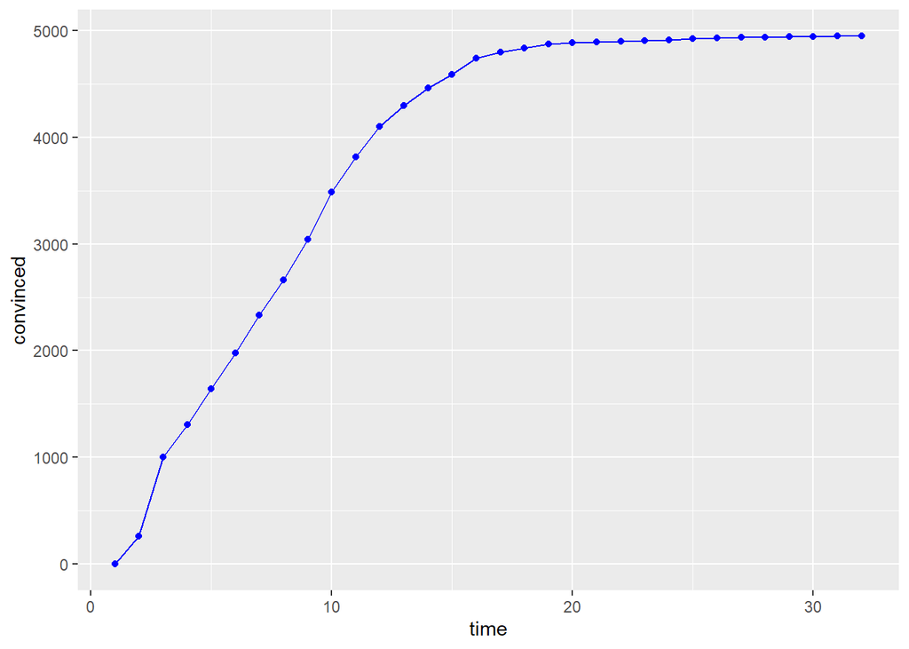

```r
kd <- coreness(G)
#max(kd)
S = c(which(kd == 10))
kd_sim<- simulation(S,q)
n_k <- length(kd_sim)

ggplot(data = data.frame(time = 1:n_k, convinced = kd_sim), aes(x=time,y=convinced))+
  geom_line(color="blue")+geom_point(color="blue")
```